# FI 362 — Chapter 2 Supplement

Linear Time Series Analysis, Step by Step on Real Data

Author

Mehman Ismayilli

Published

June 28, 2026

> **How to use this notebook.** It mirrors the Chapter 2 slides (`FI362_Ch2`) section by section, but *computes* every concept on real market data instead of stating it abstractly. Read the slide, then run the matching block here. All data lives in the sibling `data/` folder built by `data/download_data.R` (daily Yahoo Finance prices, Jan 2000 – mid 2026, adjusted for splits & dividends). **No internet is needed to run this file.**

> Where it adds value, we *hand-code* the core formula (sample ACF, Ljung–Box, Yule–Walker, the ADF regression, the GPH long-memory estimator) and then cross-check it against the standard package. Heavier packages (`forecast`, `urca`, `fracdiff`, `TSA`) are used only when installed — each block degrades gracefully.

# 1 Setup & data

```r
library(knitr)

# Optional packages: we use them if present, but never require them.
have <- function(p) requireNamespace(p, quietly = TRUE)
pk <- c(forecast = have("forecast"), urca = have("urca"),
        fracdiff = have("fracdiff"), TSA = have("TSA"),
        sandwich = have("sandwich"), lmtest = have("lmtest"))
kable(data.frame(package = names(pk), installed = unname(pk)),
      caption = "Optional packages detected on this machine.")
```

Optional packages detected on this machine.

| package | installed |
| --- | --- |
| forecast | TRUE |
| urca | TRUE |
| fracdiff | TRUE |
| TSA | FALSE |
| sandwich | FALSE |
| lmtest | TRUE |

```r
# Locate data/ robustly (works from this folder, the project root, or RStudio).
data_dir <- local({
  cands <- c("../data", "data", file.path(getwd(), "data"),
             file.path(dirname(getwd()), "data"))
  hit <- cands[file.exists(file.path(cands, "indices_adjclose.csv"))]
  if (!length(hit)) stop("Could not find data/. Run data/download_data.R first.")
  hit[1]
})

read_prices <- function(file) {
  df <- read.csv(file.path(data_dir, file), check.names = FALSE)
  df$Date <- as.Date(df$Date); df
}

indices   <- read_prices("indices_adjclose.csv")   # daily, wide (11 indices)
stocks    <- read_prices("stocks_adjclose.csv")    # daily, wide (5 US stocks)
idx_month <- read_prices("indices_monthly.csv")    # month-end, wide
sp_month  <- read_prices("sp500_monthly.csv")      # month-end S&P 500
meta      <- read.csv(file.path(data_dir, "metadata.csv"))

kable(meta[, c("symbol","name","region","asset_class","rows","start","end")],
      caption = "The universe of global indices and US stocks.")
```

The universe of global indices and US stocks.

| symbol | name | region | asset_class | rows | start | end |
| --- | --- | --- | --- | --- | --- | --- |
| ^GSPC | SP500 | United States | Equity index | 6641 | 2000-01-03 | 2026-05-29 |
| ^IXIC | NASDAQ | United States | Equity index | 6641 | 2000-01-03 | 2026-05-29 |
| ^DJI | DowJones | United States | Equity index | 6641 | 2000-01-03 | 2026-05-29 |
| ^FTSE | FTSE100 | United Kingdom | Equity index | 6719 | 2000-01-04 | 2026-05-29 |
| ^GDAXI | DAX | Germany | Equity index | 6747 | 2000-01-03 | 2026-05-29 |
| ^FCHI | CAC40 | France | Equity index | 6784 | 2000-01-03 | 2026-05-29 |
| ^N225 | Nikkei225 | Japan | Equity index | 6589 | 2000-01-04 | 2026-06-01 |
| ^HSI | HangSeng | Hong Kong | Equity index | 6583 | 2000-01-03 | 2026-05-29 |
| 000001.SS | SSEComposite | China | Equity index | 6519 | 2000-01-04 | 2026-05-29 |
| ^KS11 | KOSPI | South Korea | Equity index | 6603 | 2000-01-04 | 2026-06-01 |
| ^BSESN | Sensex | India | Equity index | 6596 | 2000-01-03 | 2026-05-29 |
| AAPL | AAPL | United States | Stock | 6641 | 2000-01-03 | 2026-05-29 |
| MSFT | MSFT | United States | Stock | 6641 | 2000-01-03 | 2026-05-29 |
| AXP | AXP | United States | Stock | 6641 | 2000-01-03 | 2026-05-29 |
| CAT | CAT | United States | Stock | 6641 | 2000-01-03 | 2026-05-29 |
| SBUX | SBUX | United States | Stock | 6641 | 2000-01-03 | 2026-05-29 |

```r
# --- returns -----------------------------------------------------------------
log_ret <- function(p) { p <- p[is.finite(p)]; diff(log(p)) }   # r_t = ln P_t - ln P_{t-1}

# month-end series from a daily (Date, price) frame
to_monthly <- function(date, price) {
  ok <- is.finite(price); date <- date[ok]; price <- price[ok]
  key <- format(date, "%Y-%m")
  idx <- tapply(seq_along(price), key, max)        # last obs in each month
  data.frame(Date = date[idx], Price = price[idx])
}

# --- sample ACF EXACTLY as on the slides -------------------------------------
samp_acf <- function(x, lag.max) {
  x <- x[is.finite(x)]; T <- length(x); xb <- mean(x)
  g0 <- sum((x - xb)^2)
  sapply(0:lag.max, function(l)
    sum((x[(l+1):T] - xb) * (x[1:(T-l)] - xb)) / g0)
}

# --- Ljung–Box Q(m) by hand --------------------------------------------------
ljung_box <- function(x, m) {
  x <- x[is.finite(x)]; T <- length(x)
  r <- samp_acf(x, m)[-1]                          # drop lag 0
  Q <- T * (T + 2) * sum(r^2 / (T - (1:m)))
  data.frame(m = m, Q = Q, df = m, p_value = 1 - pchisq(Q, m))
}

# running example: S&P 500 (index) and AAPL (stock)
# keep only rows with a finite S&P price so dates and returns stay aligned
# (the 11 global indices share one calendar, so SP500 has gaps on non-US sessions)
.ok_sp <- is.finite(indices$SP500)
sp_px  <- data.frame(Date = indices$Date[.ok_sp], Price = indices$SP500[.ok_sp])
sp_d   <- log_ret(sp_px$Price)                     # daily S&P 500 log returns
sp_m   <- log_ret(sp_month$SP500)                  # monthly S&P 500 log returns
aapl_d <- log_ret(stocks$AAPL)                     # daily AAPL log returns
aapl_m <- log_ret(to_monthly(stocks$Date, stocks$AAPL)$Price)
```

We use the **S&P 500** as the running index and **AAPL** as the running stock, but every computation is column-agnostic — swap `"SP500"` for `"DAX"`, `"AAPL"` for `"MSFT"`, etc.

# 2 Stationarity

> *Slides §2.1.* Weak stationarity = constant mean **and** an autocovariance that depends only on the lag. A stationary series fluctuates around a fixed level with constant spread; a non-stationary one wanders.

The cleanest demonstration is the same asset one difference apart: the **price** wanders (non-stationary), the **return** is anchored at zero (stationary).

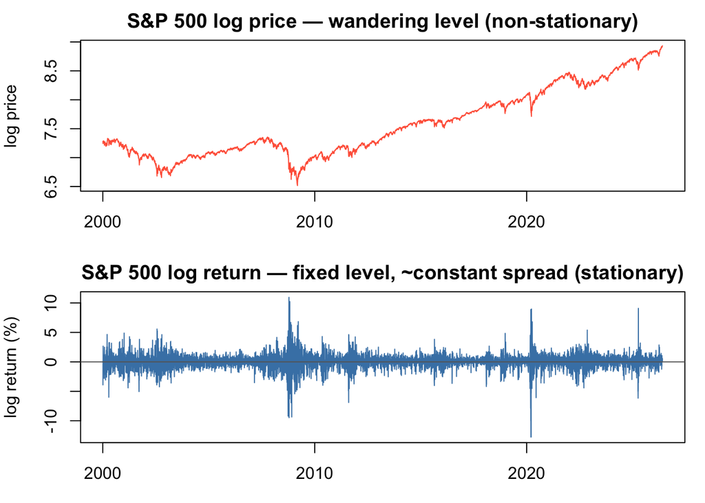

```r
op <- par(mfrow = c(2, 1), mar = c(3, 4, 2, 1))
plot(sp_px$Date, log(sp_px$Price), type = "l", col = "tomato",
     xlab = "", ylab = "log price", main = "S&P 500 log price — wandering level (non-stationary)")
plot(sp_px$Date[-1], 100 * sp_d, type = "l", col = "steelblue",
     xlab = "", ylab = "log return (%)", main = "S&P 500 log return — fixed level, ~constant spread (stationary)")
abline(h = 0, col = "grey40"); par(op)
```

A quick numerical check: split the return series in half and compare moments. For a stationary series the two halves should look alike; for the price they do not.

```r
half <- function(x) { x <- x[is.finite(x)]; n <- length(x)
  data.frame(first_mean = mean(x[1:(n%/%2)]),  second_mean = mean(x[(n%/%2+1):n]),
             first_sd   = sd(x[1:(n%/%2)]),    second_sd   = sd(x[(n%/%2+1):n])) }
kable(rbind(`log price` = half(log(sp_px$Price)),
            `log return` = half(sp_d)),
      digits = 4, caption = "Mean/SD across the two halves of the sample.")
```

Mean/SD across the two halves of the sample.

|  | first_mean | second_mean | first_sd | second_sd |
| --- | --- | --- | --- | --- |
| log price | 7.0849 | 8.0644 | 0.1623 | 0.4173 |
| log return | 0.0000 | 0.0005 | 0.0134 | 0.0108 |

# 3 Correlation and the ACF

> *Slides §2.2.* $\rho_\ell=\gamma_\ell/\gamma_0$. Under i.i.d., $\hat\rho_\ell\sim N(0,1/T)$, so bands are $\pm1.96/\sqrt T$. The Ljung–Box statistic $Q(m)=T(T+2)\sum_{\ell=1}^m\hat\rho_\ell^2/(T-\ell)\to\chi^2_m$.

**Hand-coded vs built-in ACF** — they agree to machine precision:

```r
hand <- samp_acf(sp_d, 10)[-1]
base <- as.numeric(acf(sp_d, lag.max = 10, plot = FALSE)$acf)[-1]
kable(data.frame(lag = 1:10, hand_coded = hand, base_acf = base,
                 diff = hand - base), digits = 6,
      caption = "Sample ACF of daily S&P 500 returns: our formula vs acf().")
```

Sample ACF of daily S&P 500 returns: our formula vs acf().

| lag | hand_coded | base_acf | diff |
| --- | --- | --- | --- |
| 1 | -0.099121 | -0.099121 | 0 |
| 2 | -0.003864 | -0.003864 | 0 |
| 3 | 0.003236 | 0.003236 | 0 |
| 4 | -0.025729 | -0.025729 | 0 |
| 5 | -0.010560 | -0.010560 | 0 |
| 6 | -0.031045 | -0.031045 | 0 |
| 7 | 0.026879 | 0.026879 | 0 |
| 8 | -0.026409 | -0.026409 | 0 |
| 9 | 0.038380 | 0.038380 | 0 |
| 10 | -0.000140 | -0.000140 | 0 |

**Frequency changes the verdict.** Daily index returns carry a clear negative lag-1 autocorrelation (bid–ask bounce / micro mean-reversion); monthly returns are indistinguishable from white noise.

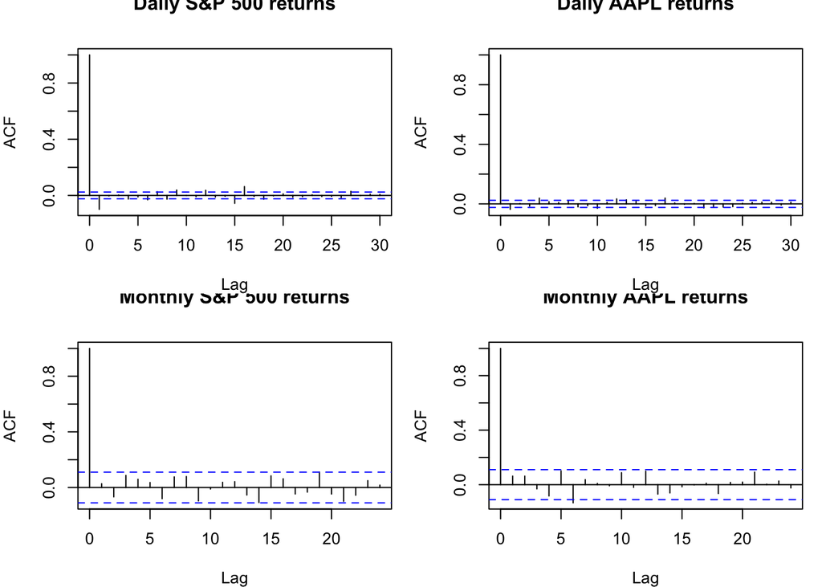

```r
op <- par(mfrow = c(2, 2), mar = c(4, 4, 2.5, 1))
acf(sp_d,   lag.max = 30, main = "Daily S&P 500 returns")
acf(aapl_d, lag.max = 30, main = "Daily AAPL returns")
acf(sp_m,   lag.max = 24, main = "Monthly S&P 500 returns")
acf(aapl_m, lag.max = 24, main = "Monthly AAPL returns"); par(op)
```

**Ljung–Box, hand-coded vs `Box.test`:**

```r
lb <- rbind(
  cbind(series = "S&P daily",   ljung_box(sp_d, 10)),
  cbind(series = "S&P monthly", ljung_box(sp_m, 5)),
  cbind(series = "S&P monthly", ljung_box(sp_m, 12)),
  cbind(series = "AAPL daily",  ljung_box(aapl_d, 10)))
kable(lb, digits = 4, caption = "Ljung–Box (hand-coded).")
```

Ljung–Box (hand-coded).

| series | m | Q | df | p_value |
| --- | --- | --- | --- | --- |
| S&P daily | 10 | 96.2229 | 10 | 0.0000 |
| S&P monthly | 5 | 5.6827 | 5 | 0.3383 |
| S&P monthly | 12 | 15.8829 | 12 | 0.1967 |
| AAPL daily | 10 | 35.3402 | 10 | 0.0001 |

```r
# cross-check one of them against the base function
c(hand = ljung_box(sp_d, 10)$p_value,
  base = Box.test(sp_d, lag = 10, type = "Ljung-Box")$p.value)
```

```
        hand         base
3.330669e-16 3.330669e-16
```

Read-off: daily returns reject “no serial correlation” decisively ($p<10^{-15}$); monthly returns do **not** ($p\approx0.20$). Markets are closer to efficient at the monthly horizon.

# 4 White noise & linear time series

> *Slides §2.3.* White noise $\{a_t\}$ is i.i.d. with mean 0, finite variance, all ACFs zero. A *linear* series is $r_t=\mu+\sum_{i\ge0}\psi_i a_{t-i}$ with $\psi_0=1$; the $\psi$-weights are the impulse response and give the variance, ACF, and forecast-error variance.

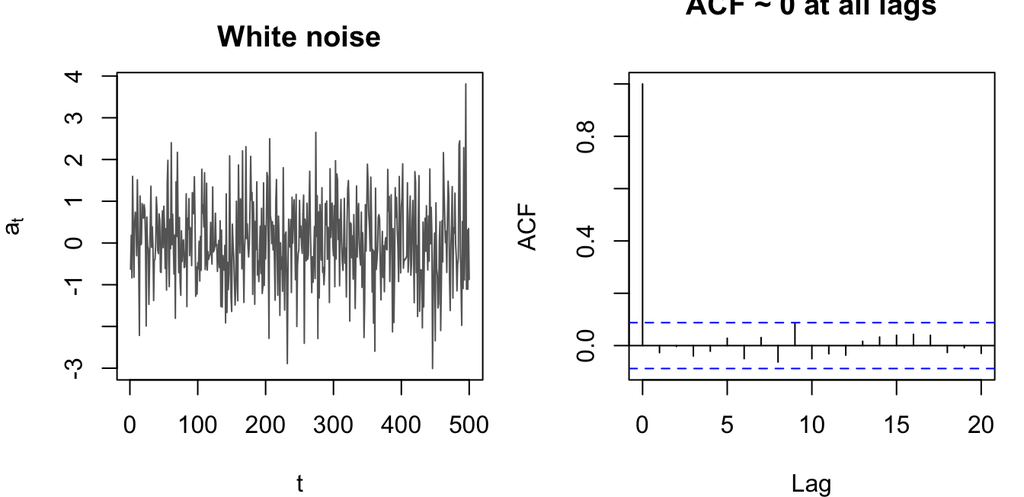

```r
set.seed(1)
a <- rnorm(500)                                    # Gaussian white noise
op <- par(mfrow = c(1, 2), mar = c(4, 4, 2.5, 1))
plot(a, type = "l", col = "grey40", main = "White noise", xlab = "t", ylab = expression(a[t]))
acf(a, lag.max = 20, main = "ACF ~ 0 at all lags"); par(op)
```

The $\psi$-weights make AR/MA/ARMA a single family. For an AR(1) with $\phi=0.6$, $\psi_i=\phi^i$, and the theoretical variance $\sigma_a^2\sum\psi_i^2$ matches a simulation:

```r
phi <- 0.6; psi <- phi^(0:200)
theo_var <- 1 * sum(psi^2)                          # sigma_a^2 = 1
set.seed(2); sim <- as.numeric(arima.sim(list(ar = phi), n = 1e5))
c(theoretical = theo_var, `closed form 1/(1-phi^2)` = 1/(1 - phi^2),
  simulated = var(sim))
```

```
            theoretical closed form 1/(1-phi^2)               simulated
               1.562500                1.562500                1.570892
```

# 5 Autoregressive (AR) models

> *Slides §2.4.* AR(1): $r_t=\phi_0+\phi_1 r_{t-1}+a_t$, stationary iff $|\phi_1|<1$, with $\rho_\ell=\phi_1^\ell$. PACF cuts off at the order $p$.

**Theoretical ACFs** (AR(1) and AR(2) via the Yule–Walker recursion):

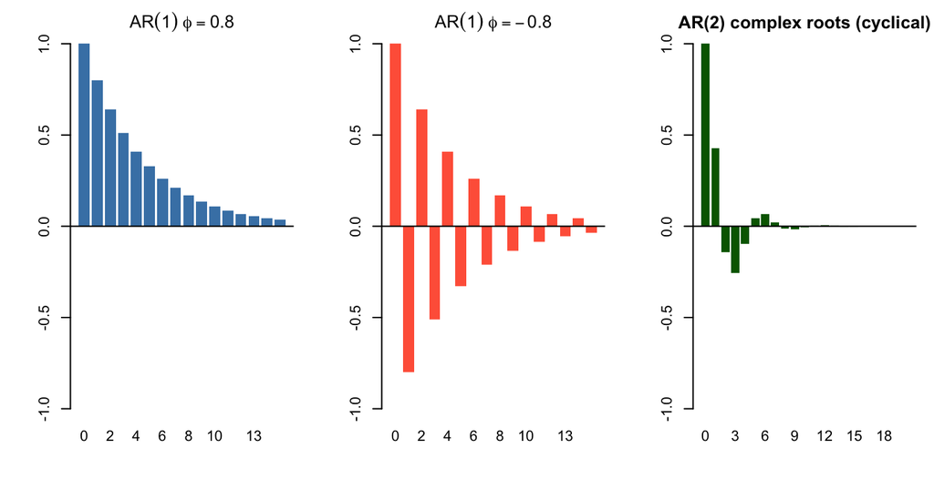

```r
ar2_acf <- function(p1, p2, n = 20) {
  r <- numeric(n + 1); r[1] <- 1; r[2] <- p1 / (1 - p2)
  for (k in 3:(n + 1)) r[k] <- p1 * r[k-1] + p2 * r[k-2]; r
}
op <- par(mfrow = c(1, 3), mar = c(4, 4, 2.5, 1))
barplot(0.8^(0:15),  names.arg = 0:15, col = "steelblue", border = NA,
        main = expression(AR(1)~phi==0.8), ylim = c(-1,1)); abline(h = 0)
barplot((-0.8)^(0:15), names.arg = 0:15, col = "tomato", border = NA,
        main = expression(AR(1)~phi==-0.8), ylim = c(-1,1)); abline(h = 0)
barplot(ar2_acf(0.6, -0.4), names.arg = 0:20, col = "darkgreen", border = NA,
        main = "AR(2) complex roots (cyclical)", ylim = c(-1,1)); abline(h = 0)
```

```r
par(op)
```

**Fit an AR to real data.** Daily S&P 500 returns have genuine AR(1) structure. We compare the **Yule–Walker** estimate by hand to `ar()` and `arima()`:

```r
# Yule-Walker for AR(1): phi1_hat = rho1_hat
r1 <- samp_acf(sp_d, 1)[2]
yw_ar  <- ar(sp_d, order.max = 1, method = "yw",  aic = FALSE)
mle_ar <- arima(sp_d, order = c(1, 0, 0))
c(`hand (rho1)` = r1, `ar() yule-walker` = yw_ar$ar,
  `arima() css-ml` = as.numeric(coef(mle_ar)["ar1"]))
```

```
     hand (rho1) ar() yule-walker   arima() css-ml
     -0.09912083      -0.09912083      -0.09926079
```

**Order selection (AIC vs BIC).** AIC is looser and reaches for a bigger model; BIC is parsimonious and consistent.

```r
T_n <- length(sp_d)
ord <- do.call(rbind, lapply(1:7, function(p) {
  f <- arima(sp_d, order = c(p, 0, 0))
  data.frame(p = p, AIC = AIC(f), BIC = AIC(f, k = log(T_n)))
}))
kable(ord, digits = 1, caption = "AR(p) on daily S&P 500 returns: AIC vs BIC.")
```

AR(p) on daily S&P 500 returns: AIC vs BIC.

| p | AIC | BIC |
| --- | --- | --- |
| 1 | -39769.5 | -39749.1 |
| 2 | -39768.7 | -39741.5 |
| 3 | -39766.8 | -39732.7 |
| 4 | -39769.1 | -39728.3 |
| 5 | -39768.7 | -39721.1 |
| 6 | -39774.7 | -39720.3 |
| 7 | -39775.4 | -39714.2 |

```r
cat(sprintf("AIC picks p = %d ; BIC picks p = %d\n",
            ord$p[which.min(ord$AIC)], ord$p[which.min(ord$BIC)]))
```

```
AIC picks p = 7 ; BIC picks p = 1
```

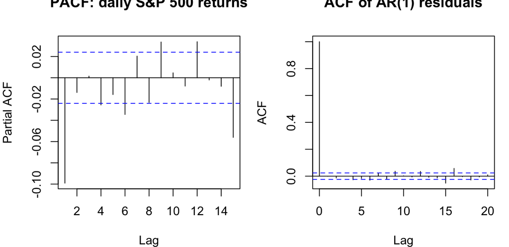

```r
op <- par(mfrow = c(1, 2), mar = c(4, 4, 2.5, 1))
pacf(sp_d, lag.max = 15, main = "PACF: daily S&P 500 returns")
acf(residuals(mle_ar), lag.max = 20, main = "ACF of AR(1) residuals"); par(op)
```

```r
# Residual Ljung-Box with df = m - p
m <- 12; Q <- ljung_box(residuals(mle_ar), m)$Q
data.frame(Q = Q, df = m - 1, p_value = 1 - pchisq(Q, m - 1))
```

| Q | df | p_value |
| --- | --- | --- |
| 37.21297 | 11 | 0.0001061356 |

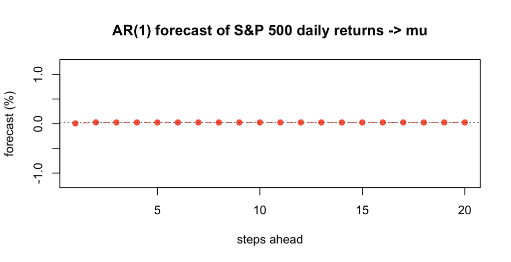

```r
pr <- predict(mle_ar, n.ahead = 20)
mu <- as.numeric(coef(mle_ar)["intercept"])
plot(1:20, 100 * pr$pred, type = "b", pch = 19, col = "tomato", ylim = c(-1.2, 1.2),
     xlab = "steps ahead", ylab = "forecast (%)",
     main = "AR(1) forecast of S&P 500 daily returns -> mu")
lines(1:20, 100 * (pr$pred + 1.96 * pr$se), lty = 2, col = "steelblue")
lines(1:20, 100 * (pr$pred - 1.96 * pr$se), lty = 2, col = "steelblue")
abline(h = 100 * mu, col = "grey40", lty = 3)
```

# 6 Moving-average (MA) models

> *Slides §2.5.* MA(1): $r_t=c_0+a_t-\theta_1 a_{t-1}$. Always stationary; ACF cuts off at lag $q$; $\rho_1=-\theta_1/(1+\theta_1^2)$ with $|\rho_1|\le0.5$.

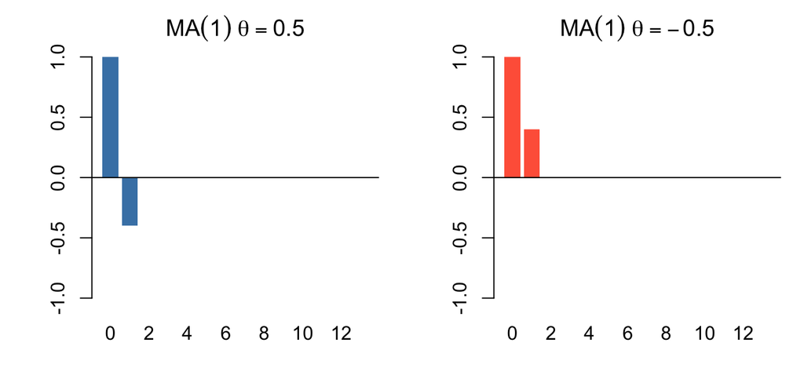

```r
ma1_acf <- function(th) c(1, -th / (1 + th^2), rep(0, 12))
op <- par(mfrow = c(1, 2), mar = c(4, 4, 2.5, 1))
barplot(ma1_acf(0.5),  names.arg = 0:13, col = "steelblue", border = NA,
        main = expression(MA(1)~theta==0.5), ylim = c(-1,1)); abline(h = 0)
barplot(ma1_acf(-0.5), names.arg = 0:13, col = "tomato", border = NA,
        main = expression(MA(1)~theta==-0.5), ylim = c(-1,1)); abline(h = 0)
```

```r
par(op)
```

The MA(1) ceiling $|\rho_1|\le0.5$ is worth seeing — it is reached only as $|\theta|\to1$ (the invertibility boundary):

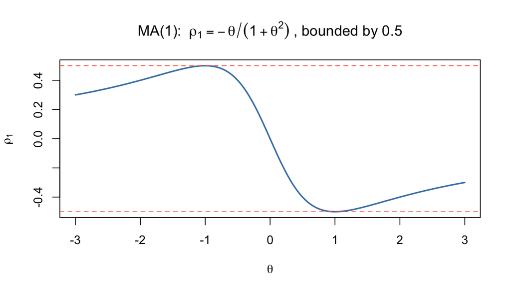

```r
th <- seq(-3, 3, 0.01); rho1 <- -th / (1 + th^2)
plot(th, rho1, type = "l", col = "steelblue", lwd = 2,
     xlab = expression(theta), ylab = expression(rho[1]),
     main = expression("MA(1): " ~ rho[1] == -theta/(1+theta^2) ~ ", bounded by 0.5"))
abline(h = c(-0.5, 0.5), lty = 2, col = "tomato")
```

Fitting an MA(1) to daily S&P returns recovers a negative $\rho_1$ consistent with the bid–ask-bounce story (an MA(1) and an AR(1) both rationalise that one spike — diagnostics and parsimony decide):

```r
ma1 <- arima(sp_d, order = c(0, 0, 1))
data.frame(theta1 = coef(ma1)["ma1"], implied_rho1 = samp_acf(sp_d,1)[2],
           resid_LB12_p = ljung_box(residuals(ma1), 12)$p_value)
```

|  | theta1 | implied_rho1 | resid_LB12_p |
| --- | --- | --- | --- |
| ma1 | -0.1010707 | -0.09912083 | 0.0002741373 |

# 7 ARMA models

> *Slides §2.6.* ARMA mixes AR and MA for parsimony; both ACF and PACF tail off. Three representations: ARMA form, MA($\infty$) ($\psi$-weights), AR($\infty$) ($\pi$-weights).

**Both functions tail off** — the fingerprint of a mixed model:

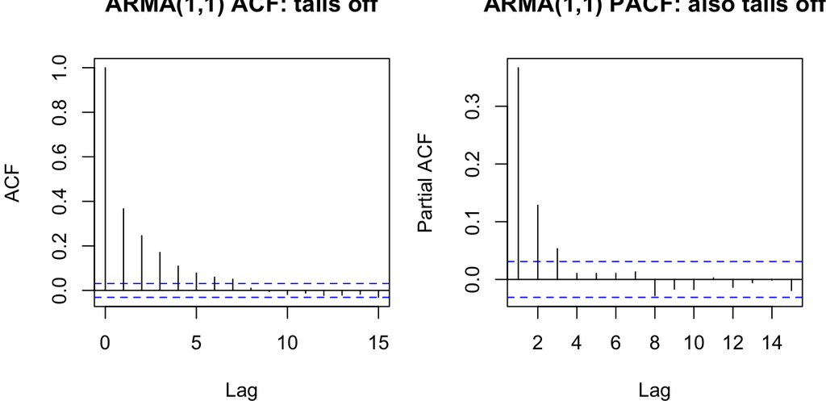

```r
set.seed(3)
x <- arima.sim(list(ar = 0.7, ma = -0.4), n = 4000)
op <- par(mfrow = c(1, 2), mar = c(4, 4, 2.5, 1))
acf(x, lag.max = 15, main = "ARMA(1,1) ACF: tails off")
pacf(x, lag.max = 15, main = "ARMA(1,1) PACF: also tails off"); par(op)
```

```r
ar_c <- 0.7; ma_c <- -0.4
# MA(inf): psi(B) = theta(B)/phi(B)  -- impulse response
psi <- ARMAtoMA(ar = ar_c, ma = ma_c, lag.max = 6)
# AR(inf): pi(B) = phi(B)/theta(B). Base R has no ARMAtoAR, but pi-weights are
# the MA(inf) expansion with the AR and MA polynomials swapped (and negated).
pii <- ARMAtoMA(ar = -ma_c, ma = -ar_c, lag.max = 6)
kable(data.frame(lag = 1:6, psi_MAinf = psi, pi_ARinf = pii), digits = 4,
      caption = "psi-weights (impulse response) and pi-weights (forecast weights).")
```

psi-weights (impulse response) and pi-weights (forecast weights).

| lag | psi_MAinf | pi_ARinf |
| --- | --- | --- |
| 1 | 0.3000 | -0.3000 |
| 2 | 0.2100 | -0.1200 |
| 3 | 0.1470 | -0.0480 |
| 4 | 0.1029 | -0.0192 |
| 5 | 0.0720 | -0.0077 |
| 6 | 0.0504 | -0.0031 |

**Identification on real data.** Use EACF if `TSA` is installed, otherwise `auto.arima`, otherwise a small BIC grid we code by hand:

```r
if (pk["TSA"]) {
  TSA::eacf(sp_d, ar.max = 5, ma.max = 5)
} else if (pk["forecast"]) {
  print(forecast::auto.arima(sp_d, max.p = 5, max.q = 5, seasonal = FALSE,
                             stationary = TRUE, ic = "bic", stepwise = FALSE))
} else {
  grid <- expand.grid(p = 0:3, q = 0:3)
  grid$BIC <- mapply(function(p, q)
    tryCatch(AIC(arima(sp_d, c(p,0,q)), k = log(T_n)), error = function(e) NA),
    grid$p, grid$q)
  kable(grid[order(grid$BIC), ][1:5, ], digits = 1,
        caption = "Top-5 ARMA(p,q) for daily S&P 500 by BIC (hand grid).")
}
```

```
Series: sp_d
ARIMA(1,0,0) with zero mean

Coefficients:
          ar1
      -0.0988
s.e.   0.0122

sigma^2 = 0.0001466:  log likelihood = 19886.04
AIC=-39768.07   AICc=-39768.07   BIC=-39754.47
```

# 8 Unit-root nonstationarity

> *Slides §2.7.* A random walk is an AR(1) with $\phi=1$: variance grows with $t$, shocks are permanent. Prices have a unit root; first differences (returns) do not. The ADF test has $H_0$: unit root.

**The ADF regression, by hand.** Regress $\Delta p_t$ on $p_{t-1}$ and $k$ lagged differences; the $t$-ratio on $p_{t-1}$ is the ADF statistic (compare to Dickey–Fuller critical values, **not** the normal table).

```r
adf_t <- function(y, k = 10, drift = TRUE) {
  y  <- y[is.finite(y)]; dy <- diff(y); n <- length(dy)
  Y  <- dy[(k+1):n]
  L1 <- y[(k+1):n]                                  # p_{t-1}
  X  <- sapply(1:k, function(i) dy[(k+1-i):(n-i)])  # lagged differences
  X  <- cbind(L1, X); if (drift) X <- cbind(1, X)
  fit <- lm.fit(X, Y)
  b   <- fit$coefficients; r <- fit$residuals
  s2  <- sum(r^2) / (length(Y) - ncol(X))
  XtX <- solve(crossprod(X)); se <- sqrt(s2 * diag(XtX))
  j <- if (drift) 2 else 1                          # position of L1 coefficient
  unname(b[j] / se[j])
}
lp <- log(sp_px$Price[is.finite(sp_px$Price)])
data.frame(
  series      = c("log price", "log return"),
  ADF_t       = c(adf_t(lp, drift = TRUE), adf_t(sp_d, drift = FALSE)),
  crit_5pct   = c(-2.86, -1.94),
  decision    = c("fail to reject H0 (unit root)", "reject H0 (stationary)"))
```

| series | ADF_t | crit_5pct | decision |
| --- | --- | --- | --- |
| log price | 1.044498 | -2.86 | fail to reject H0 (unit root) |
| log return | -25.030614 | -1.94 | reject H0 (stationary) |

```r
if (pk["urca"]) {
  cat("Cross-check with urca::ur.df --\n")
  print(urca::ur.df(lp,   type = "drift", lags = 10, selectlags = "AIC")@teststat)
  print(urca::ur.df(sp_d, type = "none",  lags = 10, selectlags = "AIC")@teststat)
}
```

```
Cross-check with urca::ur.df --
              tau2     phi1
statistic 1.055561 2.437372
               tau1
statistic -27.71206
```

**Random walk vs stationary (simulation).** Variance of a random walk grows linearly in $t$ — the visual signature of non-stationarity.

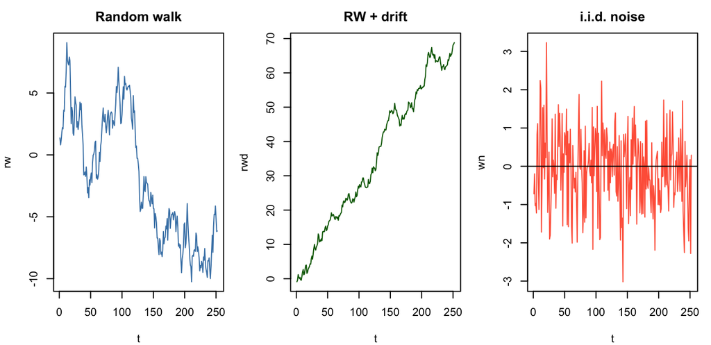

```r
set.seed(42); n <- 252
rw <- cumsum(rnorm(n)); rwd <- cumsum(rnorm(n, 0.3)); wn <- rnorm(n)
op <- par(mfrow = c(1, 3), mar = c(4, 4, 2.5, 1))
plot(rw,  type = "l", col = "steelblue", main = "Random walk", xlab = "t")
plot(rwd, type = "l", col = "darkgreen", main = "RW + drift", xlab = "t")
plot(wn,  type = "l", col = "tomato",   main = "i.i.d. noise", xlab = "t"); abline(h = 0)
```

```r
par(op)
cat(sprintf("Var of first vs second half of RW: %.2f then %.2f (grows)\n",
            var(rw[1:126]), var(rw[127:252])))
```

[output not shown]

# 9 Seasonal models

> *Slides §2.8.* Seasonal differencing $(1-B^s)$; multiplicative SARIMA $(p,d,q)\times(P,D,Q)_s$. Equity returns are **not** seasonal, so we demonstrate the *method* on a labelled simulated series and *verify* the absence of seasonality in real returns.

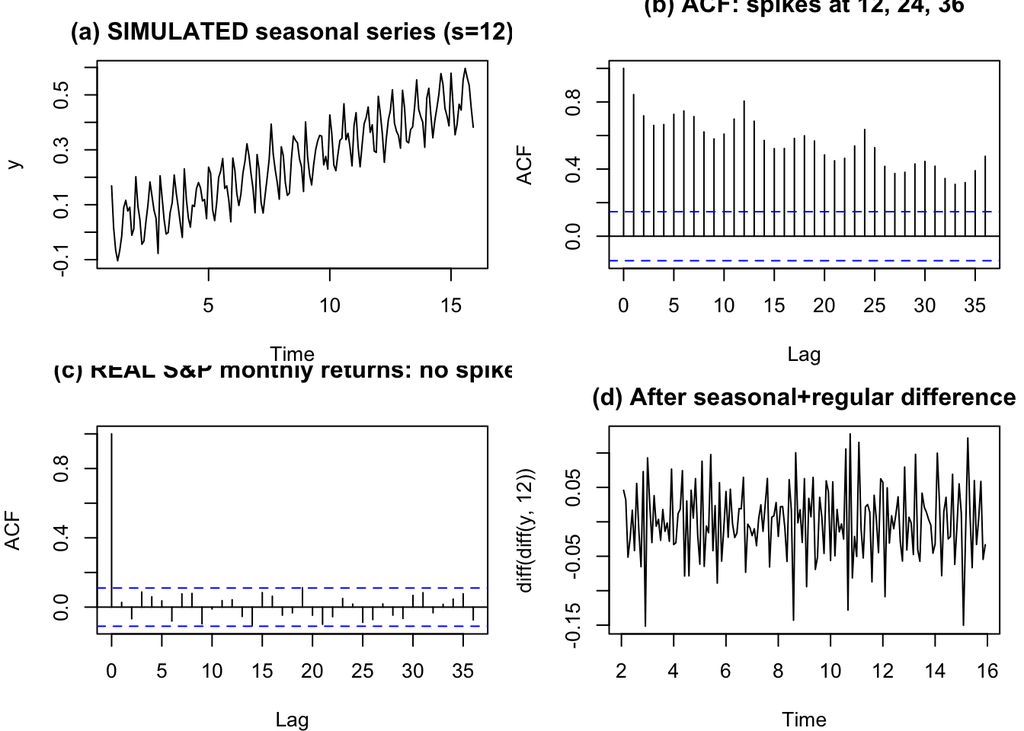

```r
set.seed(7); N <- 180
season <- rep(c(.1,.05,-.05,-.1,-.05,0,.05,.1,.05,0,-.05,-.1), N/12)
y <- ts(seq(0, .5, length.out = N) + season + rnorm(N, 0, .03),
        frequency = 12)
op <- par(mfrow = c(2, 2), mar = c(4, 4, 2.5, 1))
plot(y, main = "(a) SIMULATED seasonal series (s=12)")
acf(as.numeric(y), lag.max = 36, main = "(b) ACF: spikes at 12, 24, 36")
acf(sp_m, lag.max = 36, main = "(c) REAL S&P monthly returns: no spikes")
plot(diff(diff(y, 12)), main = "(d) After seasonal+regular difference")
```

```r
par(op)
```

```r
# the real seasonal-lag autocorrelations are tiny
data.frame(lag = c(12, 24, 36), acf = samp_acf(sp_m, 36)[c(13, 25, 37)])
```

| lag | acf |
| --- | --- |
| 12 | 0.04244213 |
| 24 | 0.01755752 |
| 36 | -0.07381239 |

```r
if (pk["forecast"])
  print(forecast::auto.arima(y, seasonal = TRUE, stepwise = FALSE, ic = "bic"))
```

```
Series: y
ARIMA(0,0,0)(2,1,0)[12] with drift

Coefficients:
         sar1     sar2   drift
      -0.5837  -0.3807  0.0027
s.e.   0.0785   0.0770  0.0001

sigma^2 = 0.001027:  log likelihood = 338.07
AIC=-668.14   AICc=-667.89   BIC=-655.64
```

# 10 Regression with time series errors

> *Slides §2.9.* When regression errors are serially correlated, OLS coefficients stay consistent but the standard errors are wrong (usually too small), so $t$-tests mislead.

We regress the **DAX level** on the **S&P 500 level** — two near-unit-root series. The slope looks wildly significant under OLS, but the residuals are massively autocorrelated.

```r
df  <- na.omit(data.frame(SP500 = indices$SP500, DAX = indices$DAX))
ols <- lm(DAX ~ SP500, data = df)
res <- residuals(ols)
cat(sprintf("beta = %.3f   OLS se = %.4f   OLS t = %.0f   R^2 = %.3f\n",
            coef(ols)[2], summary(ols)$coefficients[2,2],
            summary(ols)$coefficients[2,3], summary(ols)$r.squared))
```

```
beta = 3.241   OLS se = 0.0097   OLS t = 334   R^2 = 0.945
```

```r
cat(sprintf("Residual lag-1 ACF = %.3f   Ljung-Box(20) p = %.3g\n",
            samp_acf(res,1)[2], ljung_box(res, 20)$p_value))
```

```
Residual lag-1 ACF = 0.995   Ljung-Box(20) p = 0
```

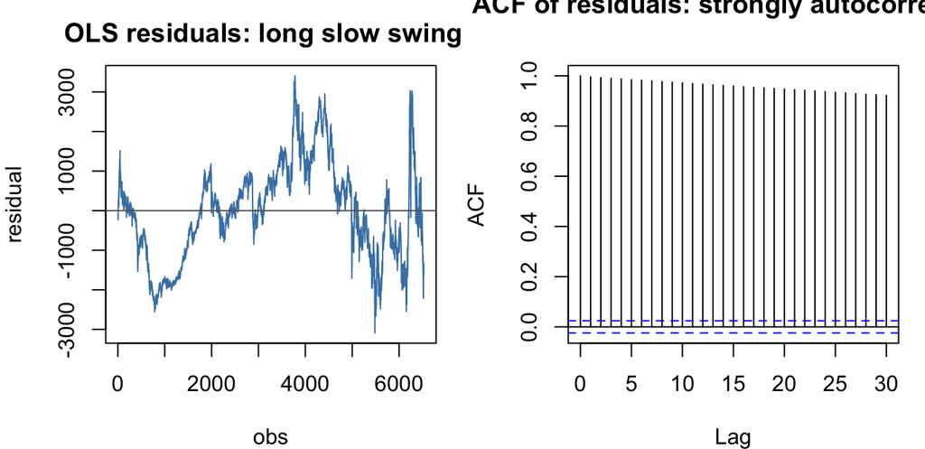

```r
op <- par(mfrow = c(1, 2), mar = c(4, 4, 2.5, 1))
plot(res, type = "l", col = "steelblue", main = "OLS residuals: long slow swings",
     xlab = "obs", ylab = "residual"); abline(h = 0, col = "grey40")
acf(res, lag.max = 30, main = "ACF of residuals: strongly autocorrelated"); par(op)
```

# 11 Consistent covariance estimation (HAC)

> *Slides §2.10.* The Newey–West / HAC estimator replaces the OLS “meat” with a Bartlett-weighted sum of residual autocovariances, restoring valid standard errors under heteroskedasticity **and** autocorrelation.

```r
hac_se <- function(model, L) {
  X <- model.matrix(model); u <- residuals(model); n <- nrow(X)
  bread <- solve(crossprod(X))
  meat  <- crossprod(X * u)                         # Gamma_0
  for (j in 1:L) {                                  # Bartlett-weighted lags
    w  <- 1 - j / (L + 1)
    Xu <- X * u
    G  <- crossprod(Xu[(j+1):n, , drop = FALSE], Xu[1:(n-j), , drop = FALSE])
    meat <- meat + w * (G + t(G))
  }
  sqrt(diag(bread %*% meat %*% bread))
}
L <- 20
hand <- hac_se(ols, L)["SP500"]
out  <- c(OLS_se = summary(ols)$coefficients["SP500","Std. Error"],
          HAC_hand = unname(hand))
if (pk["sandwich"]) out["HAC_NeweyWest"] <- sqrt(sandwich::NeweyWest(ols, lag = L)["SP500","SP500"])
out["ratio_HAC_over_OLS"] <- out["HAC_hand"] / out["OLS_se"]
kable(t(round(out, 5)), caption = "Standard error of the slope: OLS vs HAC.")
```

Standard error of the slope: OLS vs HAC.

| OLS_se | HAC_hand | ratio_HAC_over_OLS |
| --- | --- | --- |
| 0.0097 | 0.04368 | 4.50224 |

```r
if (pk["lmtest"] && pk["sandwich"])
  lmtest::coeftest(ols, vcov = sandwich::NeweyWest(ols, lag = L))
```

# 12 Long-memory models

> *Slides §2.11.* Fractional differencing $(1-B)^d x_t=a_t$, $0<d<0.5$, gives a stationary series whose ACF decays **hyperbolically**. Returns are short memory ($d\approx0$); their **volatility proxies** are long memory.

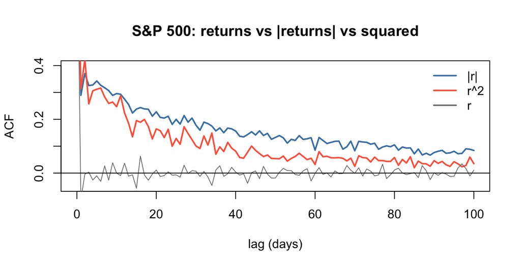

```r
L <- 100
ar_abs <- samp_acf(abs(sp_d), L); ar_sq <- samp_acf(sp_d^2, L); ar_r <- samp_acf(sp_d, L)
plot(0:L, ar_abs, type = "l", col = "steelblue", lwd = 2, ylim = c(-.05, .4),
     xlab = "lag (days)", ylab = "ACF", main = "S&P 500: returns vs |returns| vs squared")
lines(0:L, ar_sq, col = "tomato", lwd = 2); lines(0:L, ar_r, col = "grey50")
abline(h = 0); legend("topright", c("|r|","r^2","r"),
       col = c("steelblue","tomato","grey50"), lwd = 2, bty = "n")
```

**GPH estimator of $d$, by hand** (log-periodogram regression), cross-checked against `fracdiff` if installed:

```r
gph_d <- function(x, m = floor(length(x)^0.5)) {
  x <- x[is.finite(x)]; n <- length(x)
  I <- (Mod(fft(x - mean(x)))^2) / (2 * pi * n)     # periodogram
  j <- 1:m; lam <- 2 * pi * j / n
  reg <- lm(log(I[j + 1]) ~ I(-2 * log(2 * sin(lam / 2))))
  unname(coef(reg)[2])                              # slope estimates d
}
d_tab <- data.frame(series = c("|r|", "r^2", "r"),
                    GPH_d  = c(gph_d(abs(sp_d)), gph_d(sp_d^2), gph_d(sp_d)))
kable(d_tab, digits = 3, caption = "GPH long-memory estimates (d>0 => long memory).")
```

GPH long-memory estimates (d>0 => long memory).

| series | GPH_d |
| --- | --- |
| \|r\| | 0.429 |
| r^2 | 0.298 |
| r | 0.001 |

```r
if (pk["fracdiff"]) {
  fd <- fracdiff::fracdiff(abs(sp_d), nar = 0, nma = 0)
  cat(sprintf("fracdiff d for |r| = %.3f (GPH gave %.3f)\n", fd$d, gph_d(abs(sp_d))))
}
```

```
fracdiff d for |r| = 0.230 (GPH gave 0.429)
```

`d ≈ 0.4` for `|r|` versus `d ≈ 0` for `r`: volatility has long memory even though direction does not. This is precisely the empirical fact that motivates the ARCH/GARCH machinery of Chapter 3.

# 13 Key takeaways

1. **Stationarity is the licence to do inference.** Returns qualify; prices do not. One difference bridges the two.
2. **ACF/PACF classify; Ljung–Box tests.** AR ⇒ PACF cuts off; MA ⇒ ACF cuts off; ARMA ⇒ both tail off.
3. **Frequency matters.** Daily index returns carry a small negative AR(1); monthly returns are white noise. Don’t over-model.
4. **Build, then check.** Use AIC/BIC and EACF for order, but the verdict is always white-noise residuals — not a big $R^2$.
5. **Unit roots demand differencing**, not detrending; the ADF test has a non-standard distribution.
6. **Serially correlated regression errors break OLS standard errors** — fix with HAC (Newey–West) or by modelling the error process.
7. **Returns are short memory; volatility is long memory.** That single asymmetry is the doorway to Chapter 3 (ARCH/GARCH).

*Reproduce everything with `quarto render FI362_Ch2_Supplement.qmd`. Change the running series by swapping a column name — the code is column-agnostic.*